# R Notebook

Think about a model partitioning your data into pattern and residuals.

```r
library(dplyr)
library(ggplot2)
library(modelr)
options(na.action = na.warn)
library(nycflights13)
library(lubridate)
```

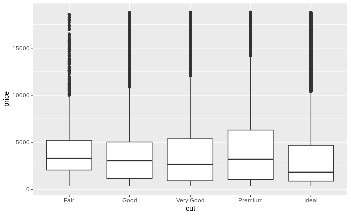

```r
ggplot(diamonds, aes(cut, price)) + geom_boxplot()
```

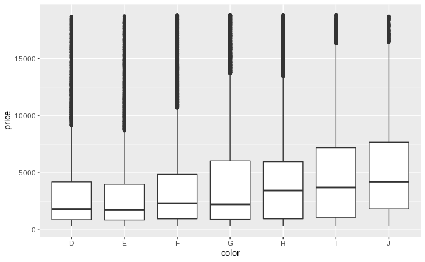

```r
ggplot(diamonds, aes(color, price)) + geom_boxplot()
```

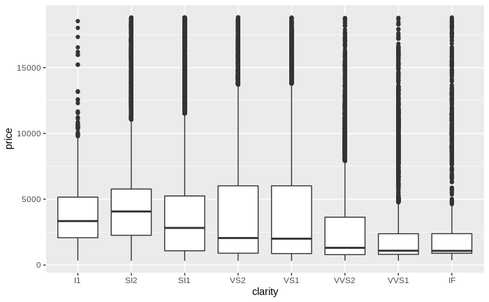

```r
ggplot(diamonds, aes(clarity, price)) + geom_boxplot()
```

Note that the worst diamond color is J (slightly yellow), and the worst clarity is I1 (inclusions visible to the naked eye).

It looks like lower quality diamonds have higher prices because there is an important confounding variable: the weight (carat) of the diamond

The weight of the diamond is the single most important factor for determining the price of the diamond, and lower quality diamonds tend to be larger.

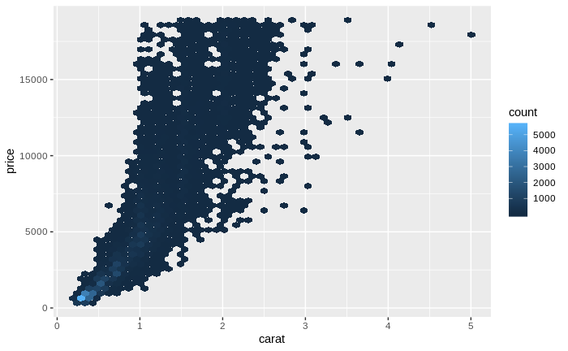

```r
ggplot(diamonds, aes(carat, price)) +
  geom_hex(bins = 50)
```

We can make it easier to see how the other attributes of a diamond affect its relative price by fitting a model to separate out the effect of carat

```r
diamonds2 <- diamonds %>%
  filter(carat <= 2.5) %>%
  mutate(lprice = log2(price), lcarat = log2(carat))
```

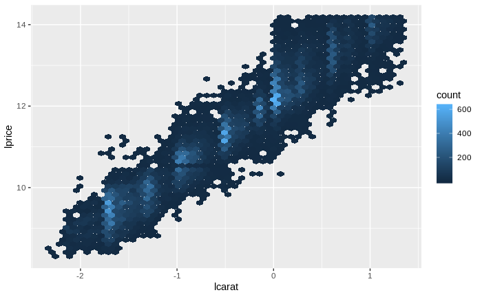

```r
ggplot(diamonds2, aes(lcarat, lprice)) +
  geom_hex(bins = 50)
```

The log-transformation is particularly useful here because it makes the pattern linear, and linear patterns are the easiest to work with. Let’s take the next step and remove that strong linear pattern. We first make the pattern explicit by fitting a model:

```r
mod_diamond <- lm(lprice ~ lcarat, data = diamonds2)
```

Then we look at what the model tells us about the data. Note that I back transform the predictions, undoing the log transformation, so I can overlay the predictions on the raw data

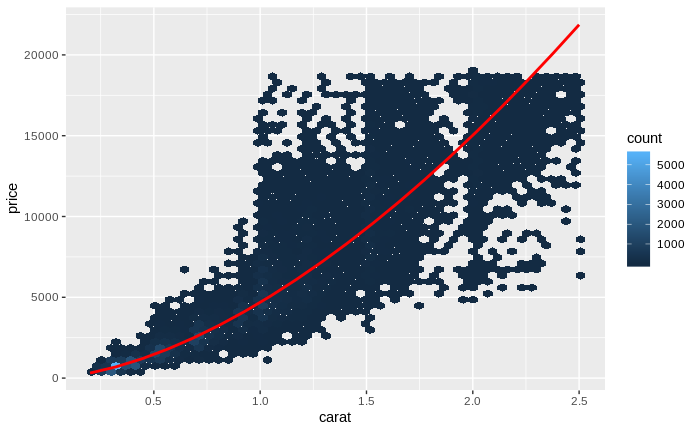

```r
grid <- diamonds2 %>%
  data_grid(carat = seq_range(carat, 20)) %>%
  mutate(lcarat = log2(carat)) %>%
  add_predictions(mod_diamond, "lprice") %>%
  mutate(price = 2 ^ lprice)
ggplot(diamonds2, aes(carat, price)) +
  geom_hex(bins = 50) +
  geom_line(data = grid, colour = "red", size = 1)
```

That tells us something interesting about our data. If we believe our model, then the large diamonds are much cheaper than expected. This is probably because no diamond in this dataset costs more than $19,000.

Now we can look at the residuals, which verifies that we’ve successfully removed the strong linear pattern:

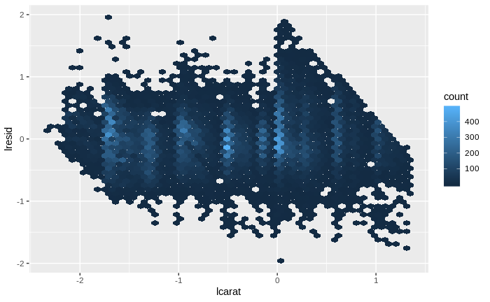

```r
diamonds2 <- diamonds2 %>%
  add_residuals(mod_diamond, "lresid")
ggplot(diamonds2, aes(lcarat, lresid)) +
  geom_hex(bins = 50)
```